# Previsão de AVC

Arnaldo Chebl

2023-11-20

## Descrição do problema e análise das métricas de desempenho

O objetivo do trabalho é prever se o paciente vai ter AVC, antes que ele de fato o tenha. Vamos utilizar o framework ‘tidymodels’ para modelar o dataset, empregando técnicas de ‘Boosting’ e ‘Random Forest’, ambas com e sem ajuste de parâmetros (‘Tuning’). Além disso, usaremos o Keras para desenvolver um modelo baseado em rede neural. Nosso foco principal será minimizar falsos negativos, visando identificar com antecedência os pacientes em risco de derrame para prevenir fatalidades.

## Setup e Bibliotecas

**Clique para expandir e ver as bibliotecas carregadas**

```r
library(tidymodels)
library(skimr)
library(factoextra)
library(ggplot2)
library(plotly)
library(dplyr)
library(doParallel)
library(vip)
library(broom)

library(knitr)

library("reticulate")
reticulate::use_python("C:/Users/arnch/anaconda3/python.exe")

library(keras)
mnist <- dataset_mnist()

library(pROC)

library(conflicted)
conflict_prefer("select", "dplyr")
conflict_prefer("filter", "dplyr")
```

## Input da Base e ajustes básicos

### Verifica tipos e nulos

**Clique para expandir**

```r
df <- read.csv("healthcare-dataset-stroke-data.csv")

df  %>%
   lapply(type_sum) %>%
   as_tibble() %>%
   pivot_longer(cols = 1:ncol(df),
                names_to = "Coluna",
               values_to = "Tipo") %>%
   inner_join(
    df %>%
       summarise(across(everything(), ~sum(is.na(.)))) %>%
       pivot_longer(cols = 1:ncol(df),
                    names_to = "Coluna",
                   values_to = "Total NA")
  )
```

```
## # A tibble: 12 × 3
##    Coluna            Tipo  `Total NA`
##    <chr>             <chr>      <int>
##  1 id                int            0
##  2 gender            chr            0
##  3 age               dbl            0
##  4 hypertension      int            0
##  5 heart_disease     int            0
##  6 ever_married      chr            0
##  7 work_type         chr            0
##  8 Residence_type    chr            0
##  9 avg_glucose_level dbl            0
## 10 bmi               chr            0
## 11 smoking_status    chr            0
## 12 stroke            int            0
```

```r
df %>% glimpse()
```

```
## Rows: 5,110
## Columns: 12
## $ id                <int> 9046, 51676, 31112, 60182, 1665, 56669, 53882, 10434…
## $ gender            <chr> "Male", "Female", "Male", "Female", "Female", "Male"…
## $ age               <dbl> 67, 61, 80, 49, 79, 81, 74, 69, 59, 78, 81, 61, 54, …
## $ hypertension      <int> 0, 0, 0, 0, 1, 0, 1, 0, 0, 0, 1, 0, 0, 0, 0, 1, 0, 1…
## $ heart_disease     <int> 1, 0, 1, 0, 0, 0, 1, 0, 0, 0, 0, 1, 0, 1, 1, 0, 1, 0…
## $ ever_married      <chr> "Yes", "Yes", "Yes", "Yes", "Yes", "Yes", "Yes", "No…
## $ work_type         <chr> "Private", "Self-employed", "Private", "Private", "S…
## $ Residence_type    <chr> "Urban", "Rural", "Rural", "Urban", "Rural", "Urban"…
## $ avg_glucose_level <dbl> 228.69, 202.21, 105.92, 171.23, 174.12, 186.21, 70.0…
## $ bmi               <chr> "36.6", "N/A", "32.5", "34.4", "24", "29", "27.4", "…
## $ smoking_status    <chr> "formerly smoked", "never smoked", "never smoked", "…
## $ stroke            <int> 1, 1, 1, 1, 1, 1, 1, 1, 1, 1, 1, 1, 1, 1, 1, 1, 1, 1…
```

```r
df %>% skim() %>% View()

print(paste("Percentual de casos com derrames:", 100 * (df %>% filter(stroke == 1) %>% nrow() / nrow(df))))
```

```
## [1] "Percentual de casos com derrames: 4.87279843444227"
```

### Arruma os tipos das variáveis

**Clique para expandir**

```r
df <- df %>%
  mutate(
          gender = as.factor(gender),
          hypertension = as.factor(hypertension),
          heart_disease = as.factor(heart_disease),
          ever_married = as.factor(ever_married),
          work_type = as.factor(work_type),
          Residence_type = as.factor(Residence_type),
          smoking_status = as.factor(smoking_status),
          stroke = as.factor(stroke)
          )

df |> glimpse()
```

```
## Rows: 5,110
## Columns: 12
## $ id                <int> 9046, 51676, 31112, 60182, 1665, 56669, 53882, 10434…
## $ gender            <fct> Male, Female, Male, Female, Female, Male, Male, Fema…
## $ age               <dbl> 67, 61, 80, 49, 79, 81, 74, 69, 59, 78, 81, 61, 54, …
## $ hypertension      <fct> 0, 0, 0, 0, 1, 0, 1, 0, 0, 0, 1, 0, 0, 0, 0, 1, 0, 1…
## $ heart_disease     <fct> 1, 0, 1, 0, 0, 0, 1, 0, 0, 0, 0, 1, 0, 1, 1, 0, 1, 0…
## $ ever_married      <fct> Yes, Yes, Yes, Yes, Yes, Yes, Yes, No, Yes, Yes, Yes…
## $ work_type         <fct> Private, Self-employed, Private, Private, Self-emplo…
## $ Residence_type    <fct> Urban, Rural, Rural, Urban, Rural, Urban, Rural, Urb…
## $ avg_glucose_level <dbl> 228.69, 202.21, 105.92, 171.23, 174.12, 186.21, 70.0…
## $ bmi               <chr> "36.6", "N/A", "32.5", "34.4", "24", "29", "27.4", "…
## $ smoking_status    <fct> formerly smoked, never smoked, never smoked, smokes,…
## $ stroke            <fct> 1, 1, 1, 1, 1, 1, 1, 1, 1, 1, 1, 1, 1, 1, 1, 1, 1, 1…
```

```r
#Abaixo verificamos que a variável 'bmi', que está como character, possui valores 'N/A'.
#Vamos criar uma flag para captar a informação dos valores missing desta váriavel e vamos transformar BMI no tipo numérico.

df$bmi %>% table() %>% sort(decreasing = TRUE) %>% head()
```

```
## .
##  N/A 28.7 28.4 26.1 26.7 27.6
##  201   41   38   37   37   37
```

```r
#criamos feature flag
df$flag <- ifelse(df$bmi == "N/A", 1, 0)

df$bmi <- ifelse(df$bmi == "N/A", NA, df$bmi)

df <- df %>%
  mutate(
          flag = as.factor(flag),
          bmi = as.double(bmi),
          )

df %>% head(5) %>% glimpse()
```

```
## Rows: 5
## Columns: 13
## $ id                <int> 9046, 51676, 31112, 60182, 1665
## $ gender            <fct> Male, Female, Male, Female, Female
## $ age               <dbl> 67, 61, 80, 49, 79
## $ hypertension      <fct> 0, 0, 0, 0, 1
## $ heart_disease     <fct> 1, 0, 1, 0, 0
## $ ever_married      <fct> Yes, Yes, Yes, Yes, Yes
## $ work_type         <fct> Private, Self-employed, Private, Private, Self-emplo…
## $ Residence_type    <fct> Urban, Rural, Rural, Urban, Rural
## $ avg_glucose_level <dbl> 228.7, 202.2, 105.9, 171.2, 174.1
## $ bmi               <dbl> 36.6, NA, 32.5, 34.4, 24.0
## $ smoking_status    <fct> formerly smoked, never smoked, never smoked, smokes,…
## $ stroke            <fct> 1, 1, 1, 1, 1
## $ flag              <fct> 0, 1, 0, 0, 0
```

Análise das categorias

```r
# input de dados ----------------------------------------------------------
categorical_variables <- df %>%
  select_if(is.factor) %>%
  names()

for (i in categorical_variables) {
  cat("Variable:", i, "\n")
  print(table(df[[i]]))
  cat("\n")
}
```

```
## Variable: gender
##
## Female   Male  Other
##   2994   2115      1
##
## Variable: hypertension
##
##    0    1
## 4612  498
##
## Variable: heart_disease
##
##    0    1
## 4834  276
##
## Variable: ever_married
##
##   No  Yes
## 1757 3353
##
## Variable: work_type
##
##      children      Govt_job  Never_worked       Private Self-employed
##           687           657            22          2925           819
##
## Variable: Residence_type
##
## Rural Urban
##  2514  2596
##
## Variable: smoking_status
##
## formerly smoked    never smoked          smokes         Unknown
##             885            1892             789            1544
##
## Variable: stroke
##
##    0    1
## 4861  249
##
## Variable: flag
##
##    0    1
## 4909  201
```

```r
#há apenas um genero do tipo "outro", iremos excluí-lo pois não será possivel treinar o modelo com apenas um registro
df <- df %>% plotly::filter(gender != "Other")
```

Tratando nulos da variável ‘bmi’ com a mediana

```r
df  %>%
   lapply(type_sum) %>%
   as_tibble() %>%
   pivot_longer(cols = 1:ncol(df),
                names_to = "Coluna",
               values_to = "Tipo") %>%
   inner_join(
    df %>%
       summarise(across(everything(), ~sum(is.na(.)))) %>%
       pivot_longer(cols = 1:ncol(df),
                    names_to = "Coluna",
                   values_to = "Total NA")
  )
```

```
## # A tibble: 13 × 3
##    Coluna            Tipo  `Total NA`
##    <chr>             <chr>      <int>
##  1 id                int            0
##  2 gender            fct            0
##  3 age               dbl            0
##  4 hypertension      fct            0
##  5 heart_disease     fct            0
##  6 ever_married      fct            0
##  7 work_type         fct            0
##  8 Residence_type    fct            0
##  9 avg_glucose_level dbl            0
## 10 bmi               dbl          201
## 11 smoking_status    fct            0
## 12 stroke            fct            0
## 13 flag              fct            0
```

```r
# Aplicar mediana aos nulos
df$bmi[is.na(df$bmi)] <- median(df$bmi, na.rm=TRUE)

# Verificar nulos novamente
df  %>%
   lapply(type_sum) %>%
   as_tibble() %>%
   pivot_longer(cols = 1:ncol(df),
                names_to = "Coluna",
               values_to = "Tipo") %>%
   inner_join(
    df %>%
       summarise(across(everything(), ~sum(is.na(.)))) %>%
       pivot_longer(cols = 1:ncol(df),
                    names_to = "Coluna",
                   values_to = "Total NA")
  )
```

```
## # A tibble: 13 × 3
##    Coluna            Tipo  `Total NA`
##    <chr>             <chr>      <int>
##  1 id                int            0
##  2 gender            fct            0
##  3 age               dbl            0
##  4 hypertension      fct            0
##  5 heart_disease     fct            0
##  6 ever_married      fct            0
##  7 work_type         fct            0
##  8 Residence_type    fct            0
##  9 avg_glucose_level dbl            0
## 10 bmi               dbl            0
## 11 smoking_status    fct            0
## 12 stroke            fct            0
## 13 flag              fct            0
```

## Clusterização: k-means

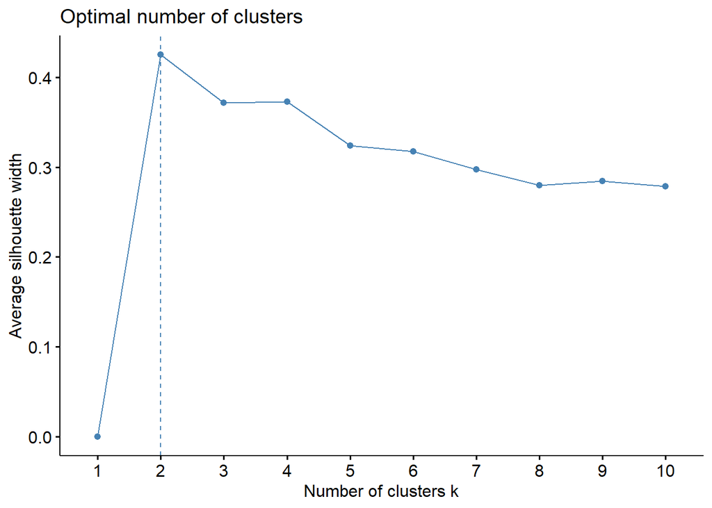

## Análise dos clusters

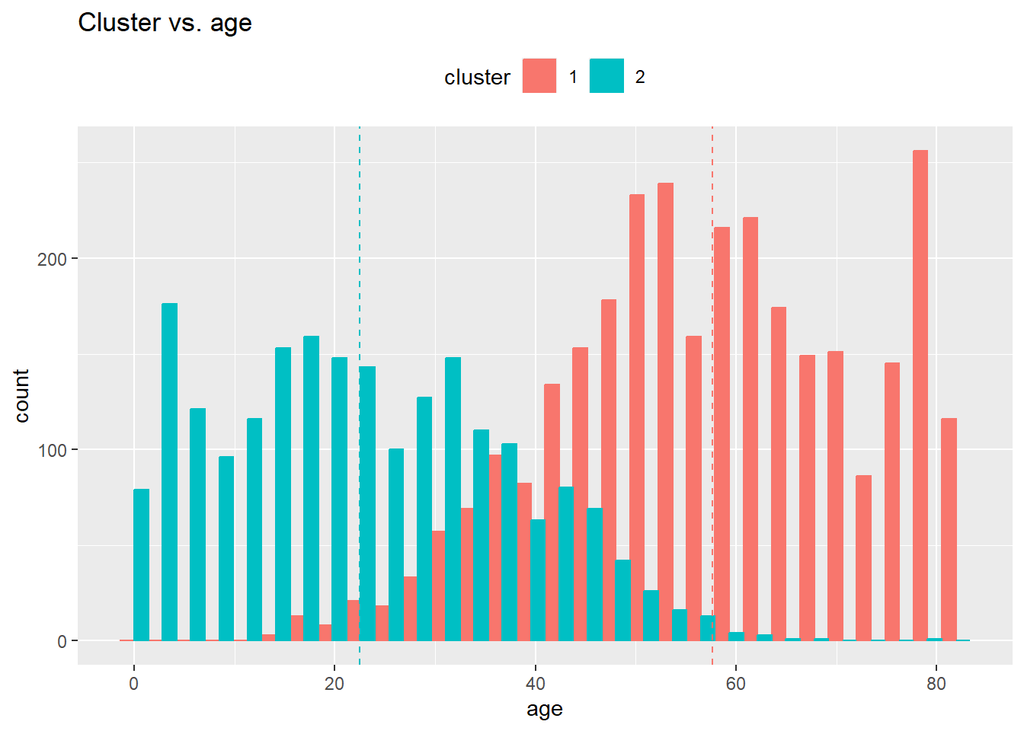

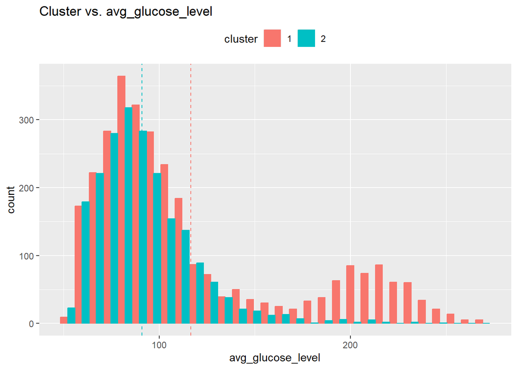

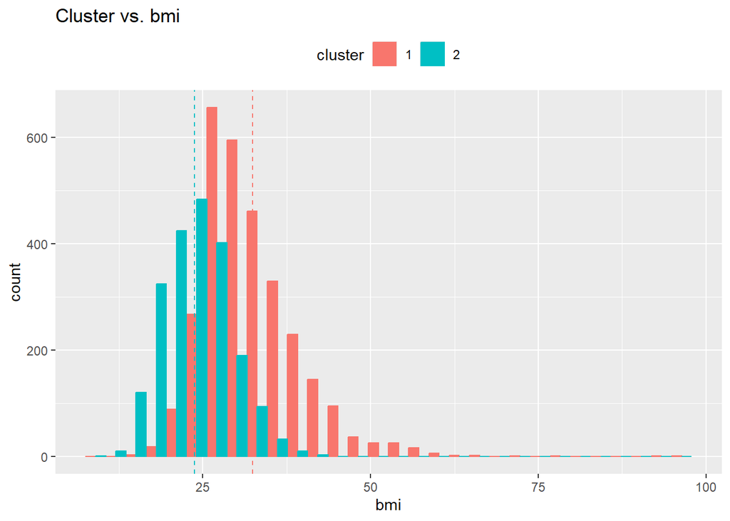

```
## # A tibble: 4 × 2
## # Groups:   cluster [2]
##   cluster pct_stroke
##   <fct>        <dbl>
## 1 1          0.920
## 2 1          0.0800
## 3 2          0.996
## 4 2          0.00381
```

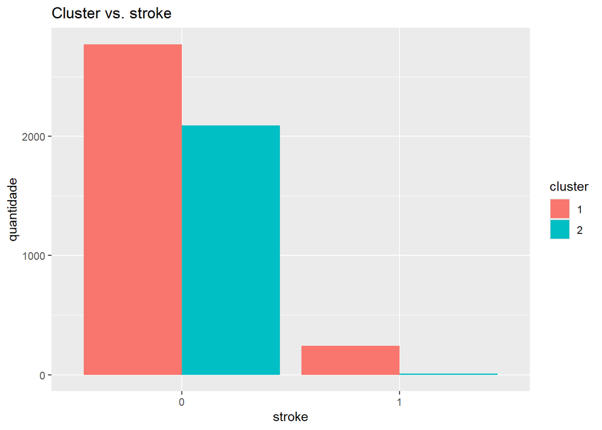

Podemos verificar que, em relação ao Cluster 2, no Cluster 1:

- As pessoas são bem mais velhas (a média é 58 x 22)
- As pessoas tem níveis de glicose mais altos (a média é 117 x 91)
- As pessoas tem níveis IMC (BMI) mais altos (a média é 32 x 24)
- AS pessoas sofrem mais infartos (8% x 0.4%)

## Análise Exploratória

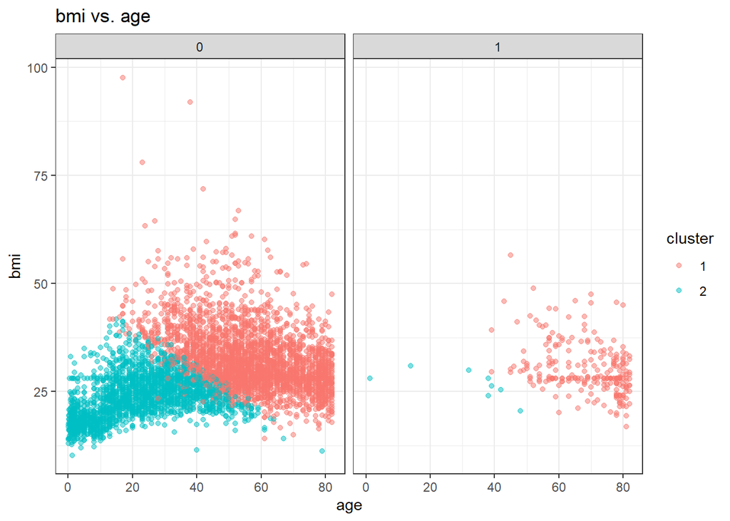

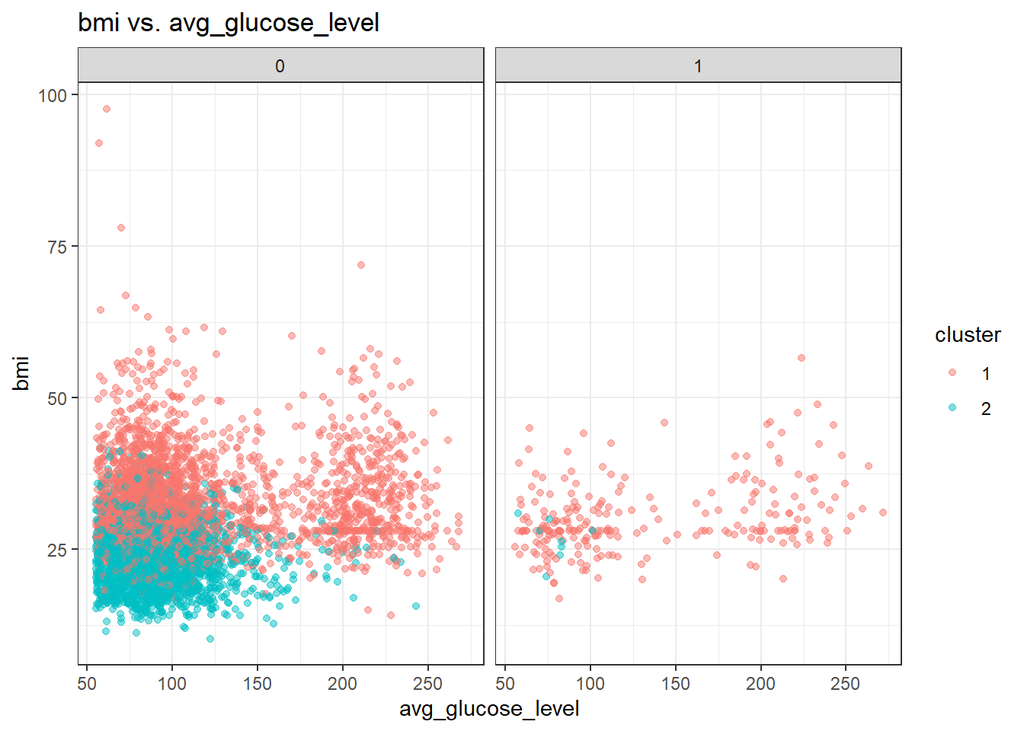

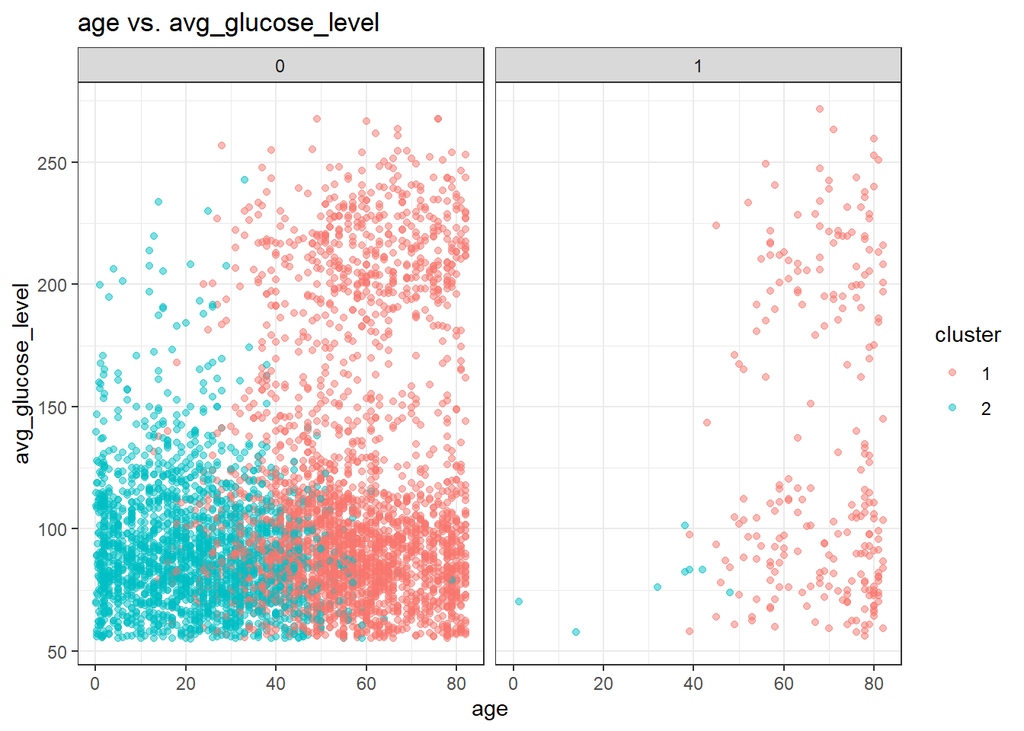

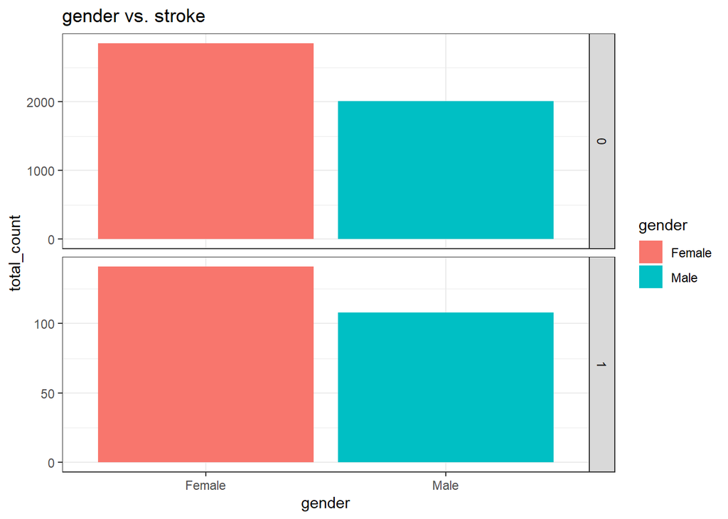

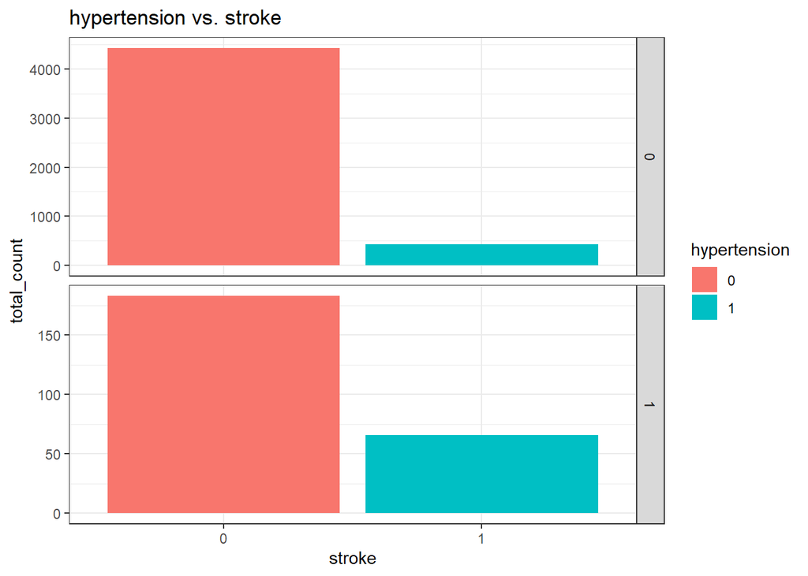

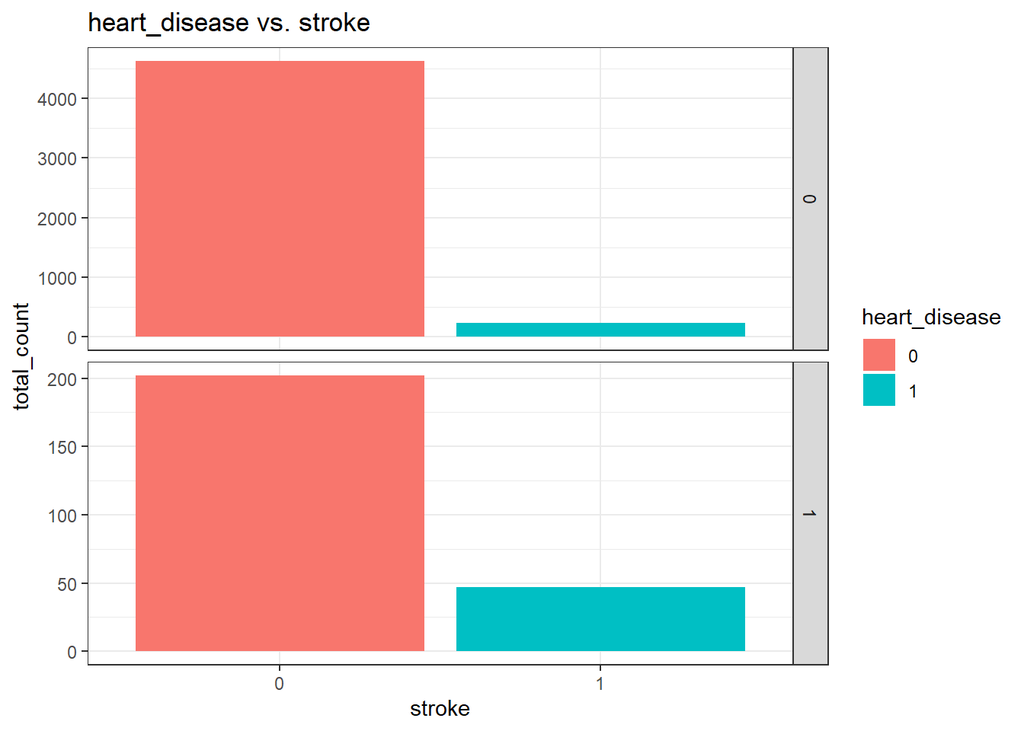

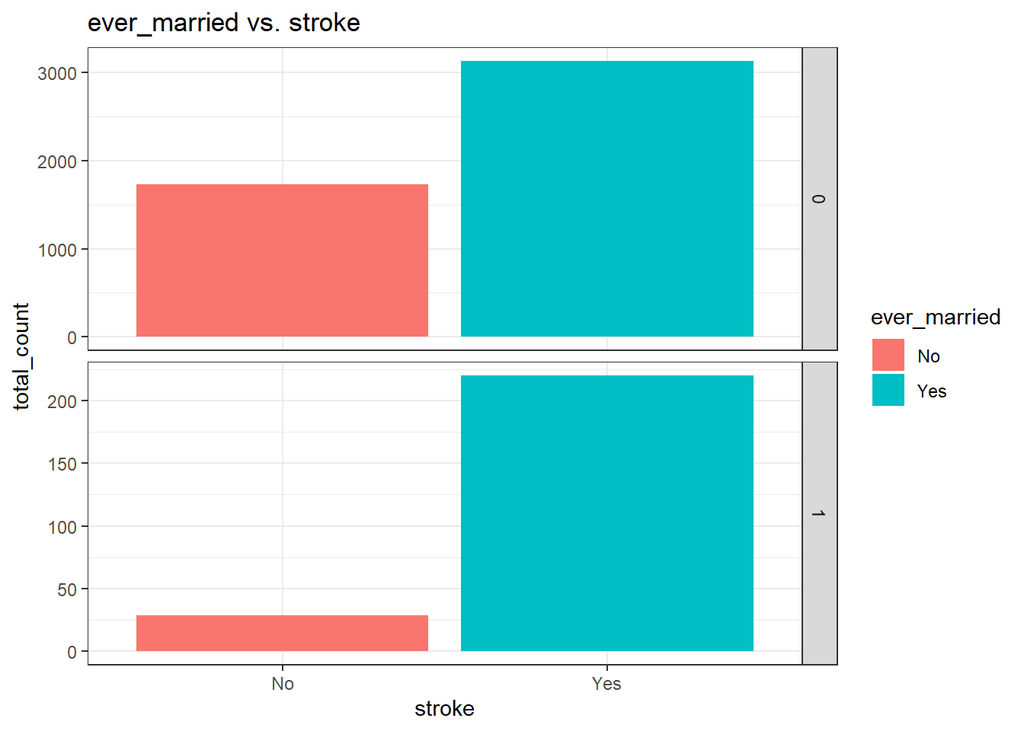

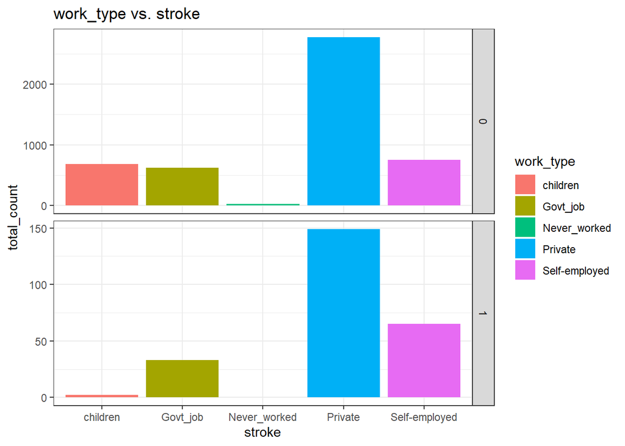

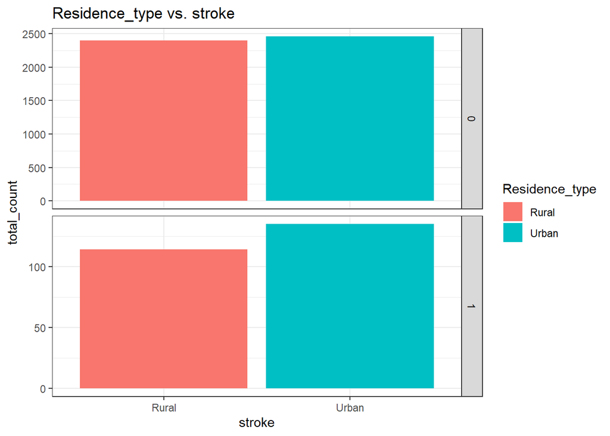

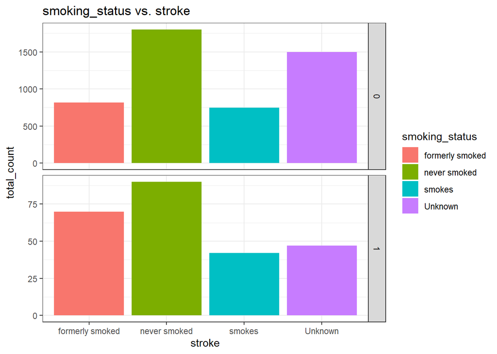

```
## [1] "verificamos necessidade de fazer log em 'bmi' e em 'avg_glucose_level', para normaliza-las"
```

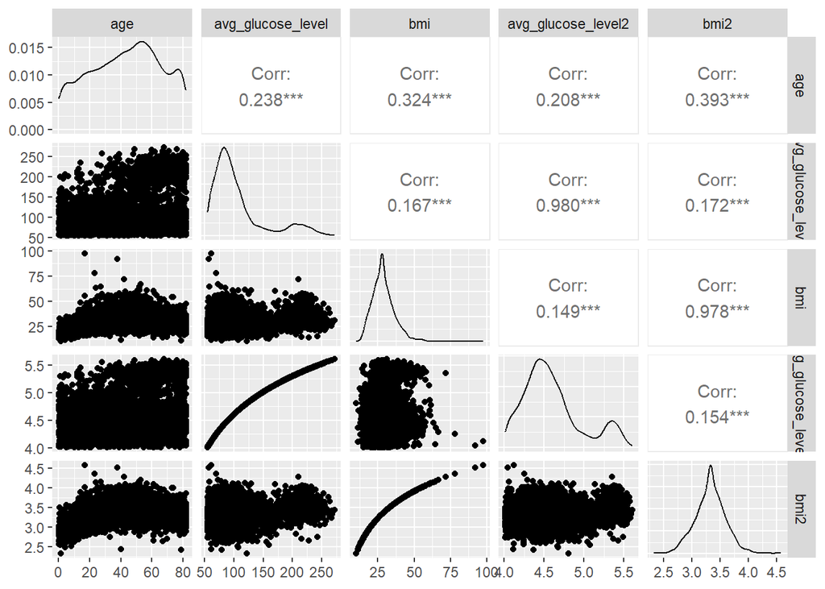

Podemos verificar que:

- **Age x BMI**: Pessoas no cluster 1 são majoritariamente mais velhas e com valores mais altos de IMC, contendo quase todos os indivíduos que tiveram derrame;
- **BMI x avg_glucose_level e age x avg_glucose_level**: maior parte dos indivíduos do cluster 2 tem nível médio de glicose abaixo de 150, enquanto no cluster 1 parece haver uma separação mais equilibrada, tendo uma concentração entre 50 e 125, e outra entre 200 e 250;
- **Gender**: A proporção de homens e mulheres dentro dos grupos de pacientes que tiveram e não tiveram derrame é parecida, indicando que o gênero não possui muita relevância para ocorrência do evento;
- **hypertension**: Pacientes com hipertensão tem maior proporção dentro do grupo que apresentou derrame em relação ao que não apresentou (26% x 8%);
- **heart_disease**: Pacientes com doenças cardiacas tem maior proporção dentro do grupo que apresentou derrame em relação ao que não apresentou (18% x 4%);
- **ever_married**: Pacientes que são ou já foram casados tem maior proporção dentro do grupo que apresentou derrame em relação ao que não apresentou (88% x 64%);
- **work_type**: Pacientes que trabalham na área privada tem proporções parecidas dentro dos grupos que tiveram e não tiveram derrame, porém autônomos (‘Self-employed’) representam 26% do grupo com derrame enquanto são apenas 15% do grupo que não apresentou;
- **Residence_type**: A proporção de pacientes que vivem em area urbana e rural dentro dos grupos de que tiveram e não tiveram derrame é parecida, indicando que o o tipo de residência não possui muita relevância para ocorrência do evento;
- **smoking_status**: formerly smoked representam 28% do grupo com derrame enquanto são apenas 16% do grupo que não apresentou, demais categorias conhecidas possuem proporções semelhantes;

## Ajuste dos modelos

### Split da base em treino e teste

**Clique para expandir**

```r
set.seed(234)
split <- initial_split(df, prop = 0.8, strata = stroke)
treinamento <- training(split)
teste <- testing(split)

prop.table(table(treinamento$stroke))
```

```
##
##       0       1
## 0.95229 0.04771
```

```r
prop.table(table(teste$stroke))
```

```
##
##       0       1
## 0.94716 0.05284
```

### Criação do Tibble de Comparativo do desempenho dos modelos

**Clique para expandir**

```r
desempenho <- tibble()
```

### Criação do recipe, prep e bake do tidymodels com interação

**Clique para expandir**

```r
# Transformação de dados - formato tidymodels -------------------------------------

set.seed(234)
#faz a receita e prepara
(receita <- recipe(stroke ~ ., data = treinamento) %>%
   step_rm(id) %>% #remove colunas selecionadas
   step_zv(all_predictors()) %>% #remove variáveis que contém um único valor
   step_log(avg_glucose_level, bmi, offset = 0) |> #melhora regressão linear e logistica se variáveis tiverem distribuição exponencial
   step_impute_median(bmi) %>% #substitui com mediana casos nulos
   step_interact(~ all_predictors():all_predictors()) %>% #cria interações entre todas as variáveis
   step_zv(all_predictors()) %>% #remove variáveis que contém um único valor
   #step_interact(~ all_predictors():all_predictors()) %>%
   step_normalize(all_numeric(), -all_outcomes()) %>%  #normaliza
   step_other(all_nominal(), -all_outcomes(), threshold = .05, other = "outros") %>% #chama de outros categorias com representatividade abaixo de 5%
   step_dummy(all_nominal(), -all_outcomes(), one_hot = TRUE) %>% #transforma categoricas em dummies contendo todas categorias nas colunas (one hot)
   step_zv(all_predictors()) #remove colunas que contem mesmo valor
   )

(receita_prep <- prep(receita))

# obtem os dados de treinamento processados
treinamento_proc <- bake(receita_prep, new_data = NULL)

# obtem os dados de teste processados
teste_proc <- bake(receita_prep, new_data = teste)
base_full_proc <- bake(receita_prep, new_data = df)
```

```r
logreg_cls_spec <-
  logistic_reg() %>%
  set_engine("glm")

set.seed(1)
fit_lm <- logreg_cls_spec %>% fit(stroke ~ ., data = treinamento_proc)

desempenho <- desempenho %>%
                bind_rows(tibble(prob = predict(fit_lm, new_data = teste_proc, type = "prob")$.pred_1,
                                classes = ifelse(teste_proc$stroke == "1", "Yes", "No"),
                                metodo = "LM - interact"))
```

Os p.valores mais significativos de cada combinação de parâmetro e seus betas estimados:

```r
tidy(fit_lm) |> arrange(p.value) |> filter(p.value < 0.05)
```

```
## # A tibble: 9 × 5
##   term                                      estimate std.error statistic p.value
##   <chr>                                        <dbl>     <dbl>     <dbl>   <dbl>
## 1 hypertension1_x_flag1                       -0.204    0.0745     -2.74 0.00616
## 2 heart_disease1_x_smoking_statussmokes        0.228    0.0864      2.64 0.00824
## 3 `heart_disease1_x_work_typeSelf-employed`   -2.28     0.911      -2.51 0.0122
## 4 heart_disease1_x_work_typePrivate           -3.25     1.36       -2.39 0.0169
## 5 heart_disease1_x_work_typeGovt_job          -1.57     0.668      -2.35 0.0187
## 6 age_x_smoking_statussmokes                  -1.19     0.528      -2.26 0.0241
## 7 heart_disease1_x_bmi                         2.88     1.35        2.14 0.0324
## 8 smoking_statussmokes_x_flag1                -0.204    0.0991     -2.06 0.0398
## 9 avg_glucose_level_x_flag1                   -1.29     0.630      -2.04 0.0410
```

### LASSO - com interação

Impacto da regularização na AUC

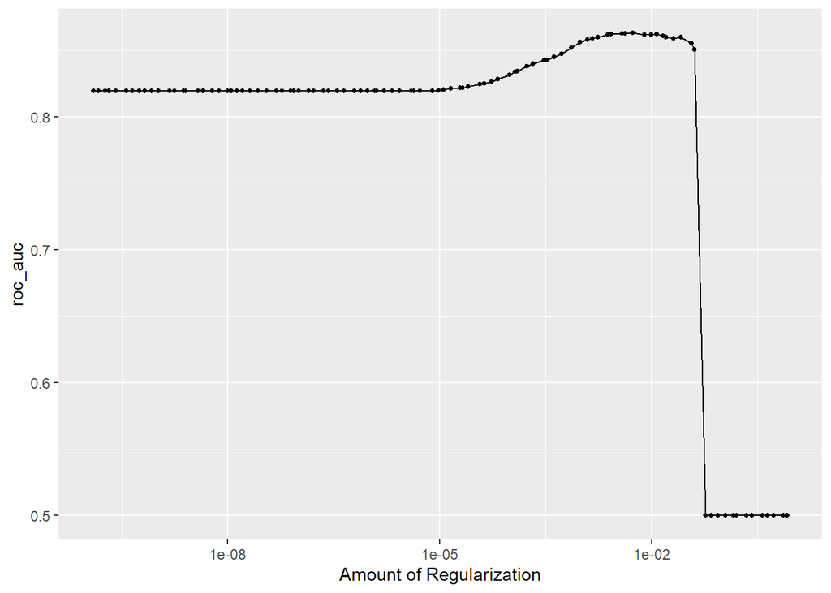

```r
# Definir os hiperparâmetros para tunagem
LASSO <- logistic_reg(penalty = tune(), mixture = 1) %>%
  set_engine("glmnet") %>%
  set_mode("classification")

# CV
set.seed(234)
cv_split <- vfold_cv(treinamento, v = 10)

# Paralelização
doParallel::registerDoParallel(makeCluster(16))

tempo <- system.time({
  LASSO_grid <- tune_grid(LASSO,
                          receita,
                          resamples = cv_split,
                          grid = 100,
                          metrics = metric_set(roc_auc))
})

autoplot(LASSO_grid)  # Plota os resultados do grid search
```

Grid dos melhores resultados de acordo com tunning de lambda/penalidade

```
## # A tibble: 6 × 7
##   penalty .metric .estimator  mean     n std_err .config
##     <dbl> <chr>   <chr>      <dbl> <int>   <dbl> <chr>
## 1 0.00536 roc_auc binary     0.863    10  0.0118 Preprocessor1_Model078
## 2 0.00425 roc_auc binary     0.863    10  0.0118 Preprocessor1_Model077
## 3 0.00382 roc_auc binary     0.863    10  0.0119 Preprocessor1_Model076
## 4 0.0119  roc_auc binary     0.862    10  0.0115 Preprocessor1_Model081
## 5 0.00266 roc_auc binary     0.862    10  0.0120 Preprocessor1_Model075
## 6 0.00792 roc_auc binary     0.862    10  0.0115 Preprocessor1_Model079
```

Variáveis e interações mais importantes pela biblioteca VIP (que mais afetam o erro do modelo caso sejam alteradas aleatoriamente)

[figure not shown]

```r
# Seleciona o melhor conjunto de hiperparâmetros
best_LASSO <- LASSO_grid %>%
  select_best("roc_auc") #select_by_one_std_err() ou select_best()

#tempo # mostra o tempo de execução

# Faz o fit do modelo com o melhor conjunto de hiperparâmetros
LASSO_fit <- finalize_model(LASSO, parameters = best_LASSO) %>%
  fit(stroke ~ ., data = treinamento_proc)

pred_LASSO <- predict(LASSO_fit, new_data = teste_proc, type = "prob")$.pred_1 #pega coluna que dá probabilidade de ter o derrame

desempenho <- desempenho %>%
                bind_rows(tibble(prob = pred_LASSO,
                                classes = ifelse(teste_proc$stroke == "1", "Yes", "No"),
                                metodo = "LASSO - interact"))

#desempenho %>% view()

# visualizando variáveis mais importantes
vip(LASSO_fit, num_features = 10, nsim = 10)
```

```r
#vip::vi(LASSO_fit, num_features = 10, nsim = 10)
```

Interações de variáveis mais importantes: de maior beta em módulo

```r
# Obter os betas em ordem decrescente
tidy(LASSO_fit) |> arrange(desc(abs(estimate))) |> head(8)
```

```
## # A tibble: 8 × 3
##   term                                  estimate penalty
##   <chr>                                    <dbl>   <dbl>
## 1 (Intercept)                            -3.79   0.00536
## 2 age_x_avg_glucose_level                 1.04   0.00536
## 3 age_x_flag1                             0.223  0.00536
## 4 age                                     0.186  0.00536
## 5 heart_disease1_x_smoking_statussmokes   0.106  0.00536
## 6 smoking_statusUnknown_x_flag1           0.0979 0.00536
## 7 age_x_hypertension1                     0.0901 0.00536
## 8 hypertension1_x_flag1                  -0.0657 0.00536
```

### Criação do recipe, prep e bake do tidymodels sem interação

**Clique para expandir**

```r
# Transformação de dados - formato tidymodels -------------------------------------

set.seed(234)
#faz a receita e prepara
(receita <- recipe(stroke ~ ., data = treinamento) %>%
   step_rm(id) %>% #remove colunas selecionadas
   step_zv(all_predictors()) %>% #remove variáveis que contém um único valor
   step_log(avg_glucose_level, bmi) |> #melhora regressão linear e logistica se variáveis tiverem crescimento exponencial
   step_impute_median(bmi) %>% #substitui com mediana casos nulos
   #step_interact(~ all_predictors():all_predictors()) %>% #cria interações entre todas as variáveis
   #step_zv(all_predictors()) %>% #remove variáveis que contém um único valor
   #step_interact(~ all_predictors():all_predictors()) %>%
   step_normalize(all_numeric(), -all_outcomes()) %>%  #normaliza
   step_other(all_nominal(), -all_outcomes(), threshold = .05, other = "outros") %>% #chama de outros categorias com representatividade abaixo de 5%
   step_dummy(all_nominal(), -all_outcomes(), one_hot = TRUE) %>% #transforma categoricas em dummies contendo todas categorias nas colunas (one hot)
   step_zv(all_predictors()) #remove colunas que contem mesmo valor
   )

(receita_prep <- prep(receita))

# obtem os dados de treinamento processados
treinamento_proc <- bake(receita_prep, new_data = NULL)

# obtem os dados de teste processados
teste_proc <- bake(receita_prep, new_data = teste)
base_full_proc <- bake(receita_prep, new_data = df)

#treinamento_proc %>% ncol()
teste %>% ncol()
```

```
## [1] 14
```

```r
teste_proc %>% ncol()
```

```
## [1] 27
```

### Regressão Linear - sem interação

Os p.valores mais significativos de cada parâmetro e seus betas estimados:

```r
logreg_cls_spec <-
  logistic_reg() %>%
  set_engine("glm")

set.seed(1)
fit_lm <- logreg_cls_spec %>% fit(stroke ~ ., data = treinamento_proc)

pred_lm <- predict(fit_lm, new_data = teste_proc, type = "prob")$.pred_1

desempenho <- desempenho %>%
                bind_rows(tibble(prob = pred_lm,
                                classes = ifelse(teste_proc$stroke == "1", "Yes", "No"),
                                metodo = "LM"))

# Carregar o pacote broom
library(broom)

tidy(fit_lm) |> arrange(p.value) |> filter(p.value < 0.05)
```

```
## # A tibble: 4 × 5
##   term              estimate std.error statistic  p.value
##   <chr>                <dbl>     <dbl>     <dbl>    <dbl>
## 1 age                  1.66     0.179       9.27 1.94e-20
## 2 flag_X0             -1.45     0.234      -6.19 6.14e-10
## 3 avg_glucose_level    0.200    0.0666      3.01 2.60e- 3
## 4 hypertension_X0     -0.414    0.186      -2.23 2.55e- 2
```

# Criação e ajuste dos modelos

### Elastic Net - sem interação

Interação das alterações dos hiperparametros lambda e alpha na AUC

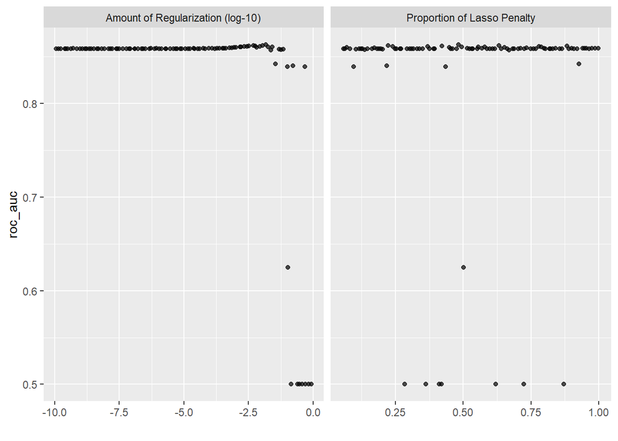

```r
# Definir os hiperparâmetros para tunagem
enet <- logistic_reg(penalty = tune(), mixture = tune()) %>%
  set_engine("glmnet") %>%
  set_mode("classification")

# CV
set.seed(234)
cv_split <- vfold_cv(treinamento, v = 10)

# Paralelização
doParallel::registerDoParallel(makeCluster(16))

tempo <- system.time({
  enet_grid <- tune_grid(enet,
                         receita,
                         resamples = cv_split,
                         grid = 100,
                         metrics = metric_set(roc_auc))
})

autoplot(enet_grid)  # Plota os resultados do grid search
```

Melhor grid de parâmetros de acordo com a métrica AUC

```r
enet_grid %>%
  collect_metrics() %>%   # Visualiza o tibble de resultados
  arrange(desc(mean)) |> head()
```

```
## # A tibble: 6 × 8
##   penalty mixture .metric .estimator  mean     n std_err .config
##     <dbl>   <dbl> <chr>   <chr>      <dbl> <int>   <dbl> <chr>
## 1 0.0146    0.482 roc_auc binary     0.862    10  0.0106 Preprocessor1_Model046
## 2 0.00491   0.631 roc_auc binary     0.862    10  0.0114 Preprocessor1_Model062
## 3 0.0112    0.223 roc_auc binary     0.862    10  0.0111 Preprocessor1_Model019
## 4 0.00328   0.421 roc_auc binary     0.861    10  0.0114 Preprocessor1_Model040
## 5 0.00580   0.882 roc_auc binary     0.861    10  0.0112 Preprocessor1_Model088
## 6 0.00850   0.779 roc_auc binary     0.861    10  0.0109 Preprocessor1_Model077
```

Variáveis mais importantes pela biblioteca VIP (que mais afetam o erro do modelo caso sejam alteradas aleatóriamente)

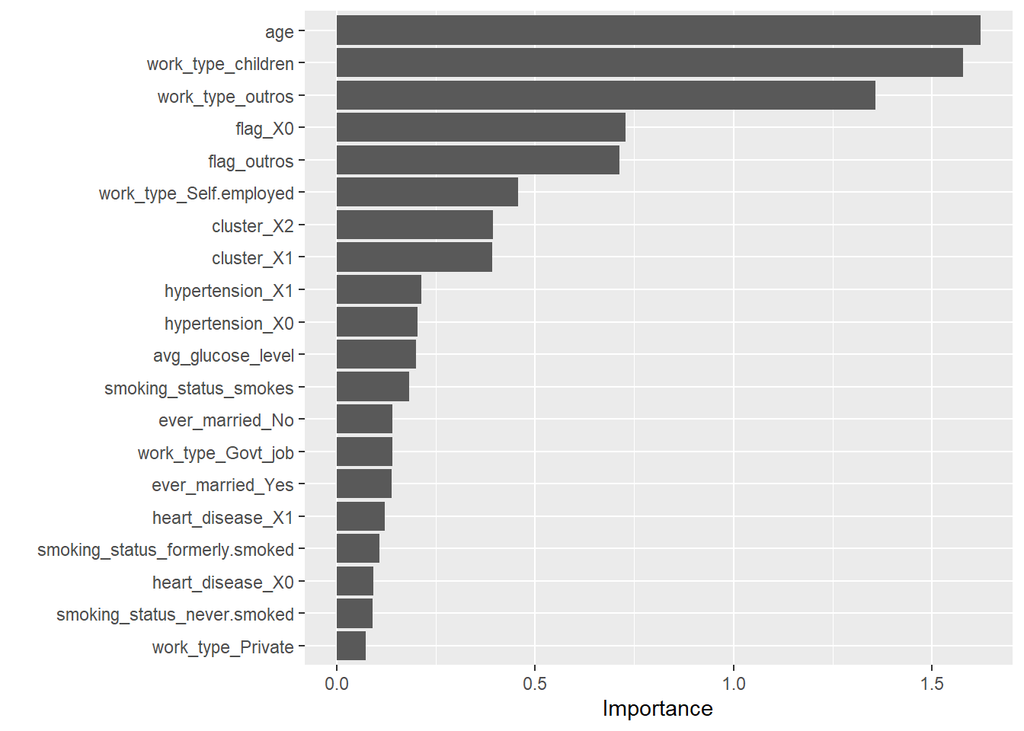

```r
# Seleciona o melhor conjunto de hiperparâmetros
best_enet <- enet_grid %>%
  select_by_one_std_err("roc_auc") #select_by_one_std_err() ou select_best()

# tempo #grid = 50, 106s

# Faz o fit do modelo com o melhor conjunto de hiperparâmetros
enet_fit <- finalize_model(enet, parameters = best_enet) %>%
  fit(stroke ~ ., data = treinamento_proc)

pred_enet <- predict(enet_fit, new_data = teste_proc, type = "prob")$.pred_1 #pega coluna que dá probabilidade de ter o derrame

desempenho <- desempenho %>%
                bind_rows(tibble(prob = pred_enet,
                                classes = ifelse(teste_proc$stroke == "1", "Yes", "No"),
                                metodo = "Elastic Net"))

#desempenho %>% view()

# visualizando variáveis mais importantes
vip(enet_fit, num_features = 20)
```

Variáveis mais importantes: de maior beta em módulo

```r
# Carregar o pacote broom
library(broom)

# Obter os coeficientes e o intercepto em ordem decrescente
tidy(enet_fit) |> arrange(desc(abs(estimate))) |> head(8)
```

```
## # A tibble: 8 × 3
##   term                    estimate    penalty
##   <chr>                      <dbl>      <dbl>
## 1 (Intercept)               -3.36  0.00000207
## 2 age                        1.62  0.00000207
## 3 work_type_children         1.58  0.00000207
## 4 work_type_outros          -1.36  0.00000207
## 5 flag_X0                   -0.728 0.00000207
## 6 flag_outros                0.712 0.00000207
## 7 work_type_Self.employed   -0.457 0.00000207
## 8 cluster_X2                -0.395 0.00000207
```

### Modelo Random Forest

Tunning dos hiperparâmetros

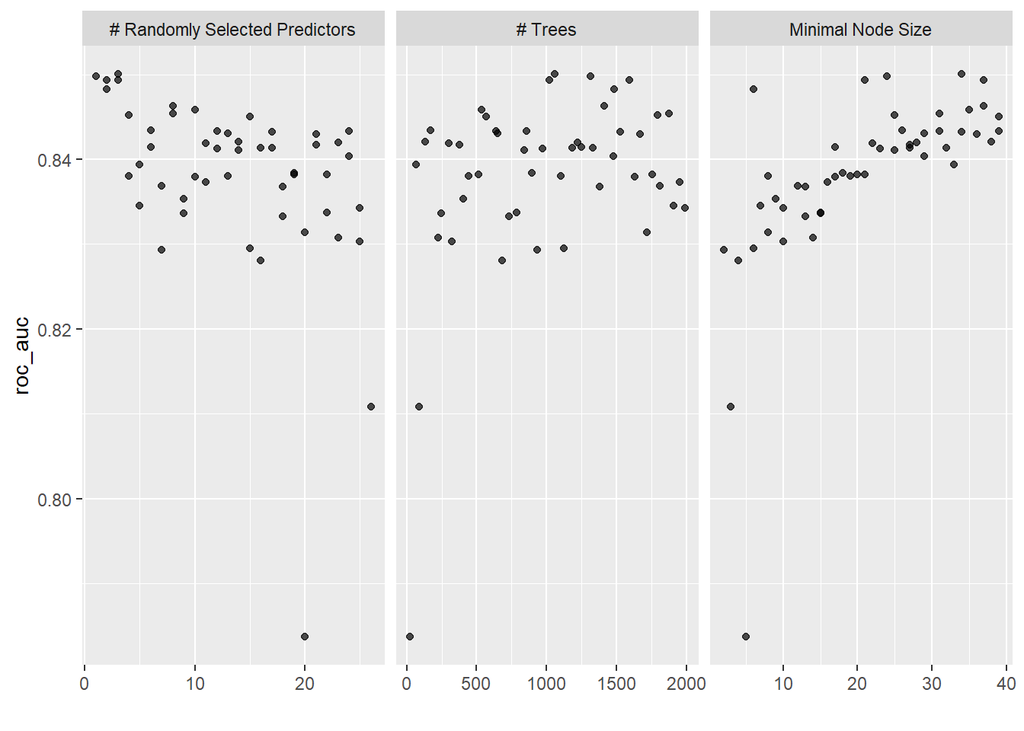

```r
# Definir os hiperparâmetros para tunagem
rf <- rand_forest(trees = tune(), mtry = tune(), min_n = tune()) %>%
  set_engine("ranger", importance = "impurity") %>%
  set_mode("classification")

# CV
set.seed(234)
cv_split <- vfold_cv(treinamento, v = 5)

# Paralelização
doParallel::registerDoParallel(makeCluster(16))

tempo <- system.time({
  rf_grid <- tune_grid(rf,
                       receita,
                       resamples = cv_split,
                       grid = 50,
                       metrics = metric_set(roc_auc))
})

autoplot(rf_grid)  # Plota os resultados do grid search
```

Melhor grid de parâmetros de acordo com a métrica AUC

```r
rf_grid %>%
  collect_metrics() %>%   # Visualiza o tibble de resultados
  arrange(desc(mean))
```

```
## # A tibble: 50 × 9
##     mtry trees min_n .metric .estimator  mean     n std_err .config
##    <int> <int> <int> <chr>   <chr>      <dbl> <int>   <dbl> <chr>
##  1     3  1061    34 roc_auc binary     0.850     5  0.0110 Preprocessor1_Model…
##  2     1  1313    24 roc_auc binary     0.850     5  0.0124 Preprocessor1_Model…
##  3     3  1018    37 roc_auc binary     0.849     5  0.0116 Preprocessor1_Model…
##  4     2  1592    21 roc_auc binary     0.849     5  0.0110 Preprocessor1_Model…
##  5     2  1486     6 roc_auc binary     0.848     5  0.0109 Preprocessor1_Model…
##  6     8  1414    37 roc_auc binary     0.846     5  0.0109 Preprocessor1_Model…
##  7    10   536    35 roc_auc binary     0.846     5  0.0111 Preprocessor1_Model…
##  8     8  1879    31 roc_auc binary     0.845     5  0.0109 Preprocessor1_Model…
##  9     4  1793    25 roc_auc binary     0.845     5  0.0101 Preprocessor1_Model…
## 10    15   570    39 roc_auc binary     0.845     5  0.0108 Preprocessor1_Model…
## # ℹ 40 more rows
```

Variáveis mais importantes pela biblioteca VIP (que mais afetam o erro do modelo caso sejam alteradas aleatóriamente)

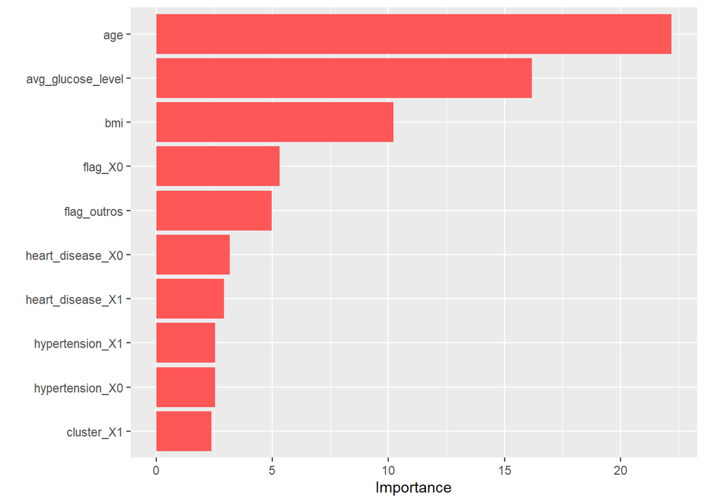

```r
# Seleciona o melhor conjunto de hiperparâmetros
best_rf <- rf_grid %>%
  select_best("roc_auc")

#tempo #grid = 50, 106s

# Faz o fit do modelo com o melhor conjunto de hiperparâmetros
rf_fit <- finalize_model(rf, parameters = best_rf) %>%
  fit(stroke ~ ., data = treinamento_proc)

pred_rf <- predict(rf_fit, new_data = teste_proc, type = "prob")$.pred_1 #pega coluna que dá probabilidade de ter o derrame

desempenho <- desempenho %>%
                bind_rows(tibble(prob = pred_rf,
                                classes = ifelse(teste_proc$stroke == "1", "Yes", "No"),
                                metodo = "Random Forest"))

#desempenho %>% view()

# visualizando variáveis mais importantes
vip(rf_fit, aesthetics = list(fill = "#FF5757"))  #melhor para explicar causalidade
```

### Modelo XGBOOST

Tunning dos hiperparâmetros

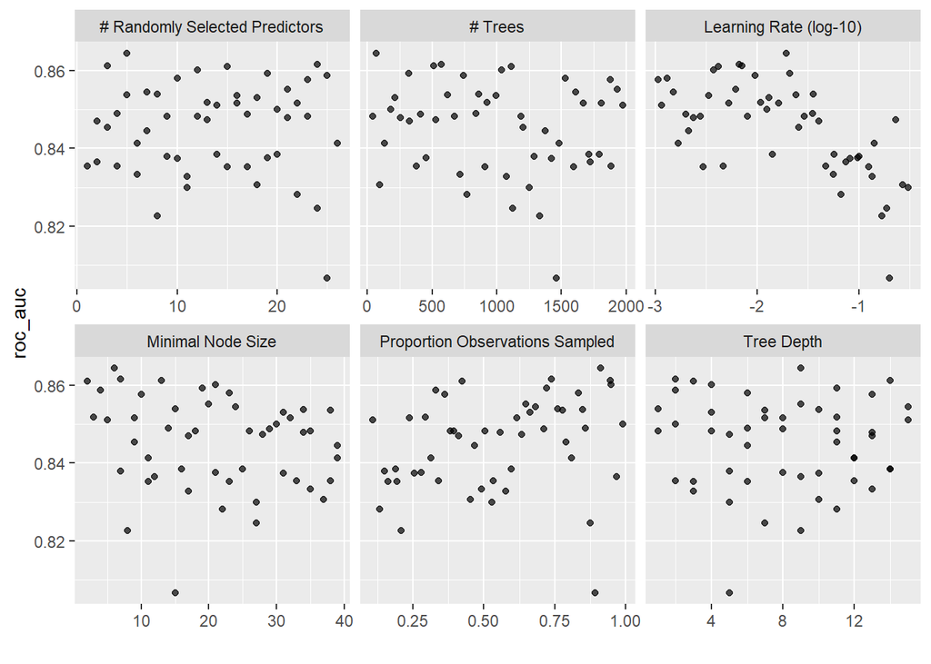

```r
boost <- boost_tree(trees = tune(), learn_rate = tune(), mtry = tune(),
                    tree_depth = tune(), min_n = tune(), sample_size = tune()) %>%
  set_engine("xgboost") %>%
  set_mode("classification")

# cv
set.seed(234)
cv_split <- vfold_cv(treinamento, v = 5)

# otimização de hiperparametro
doParallel::registerDoParallel(16) #colocar nro de cores da maquina

tempo <- system.time({
  boost_grid <- tune_grid(boost,
                          receita,
                          resamples = cv_split,
                          grid = 50,
                          metrics = metric_set(roc_auc))
})

autoplot(boost_grid) # plota os resultados do grid search
```

Melhor grid de parâmetros de acordo com a métrica AUC

```r
boost_grid %>%
  collect_metrics()  %>%   # visualiza o tibble de resultados
  arrange(desc(mean))
```

```
## # A tibble: 50 × 12
##     mtry trees min_n tree_depth learn_rate sample_size .metric .estimator  mean
##    <int> <int> <int>      <int>      <dbl>       <dbl> <chr>   <chr>      <dbl>
##  1     5    67     6          9    0.0192        0.911 roc_auc binary     0.864
##  2    24   570     7          2    0.00670       0.739 roc_auc binary     0.862
##  3     3   513    13         14    0.00708       0.946 roc_auc binary     0.861
##  4    15  1115     2          3    0.00419       0.424 roc_auc binary     0.861
##  5    12  1038    21          4    0.00376       0.948 roc_auc binary     0.860
##  6    19   320    19         11    0.0210        0.720 roc_auc binary     0.859
##  7    25   743     4          2    0.00960       0.332 roc_auc binary     0.859
##  8    10  1529    23          6    0.00131       0.834 roc_auc binary     0.858
##  9    23  1876    10         13    0.00106       0.363 roc_auc binary     0.858
## 10    21  1934    20          9    0.00617       0.649 roc_auc binary     0.855
## # ℹ 40 more rows
## # ℹ 3 more variables: n <int>, std_err <dbl>, .config <chr>
```

Variáveis mais importantes pela biblioteca VIP (que mais afetam o erro do modelo caso sejam alteradas aleatóriamente)

```r
(best_xgb <- boost_grid %>%
    select_best("roc_auc")) # salva o melhor conjunto de parametros
```

```
## # A tibble: 1 × 7
##    mtry trees min_n tree_depth learn_rate sample_size .config
##   <int> <int> <int>      <int>      <dbl>       <dbl> <chr>
## 1     5    67     6          9     0.0192       0.911 Preprocessor1_Model08
```

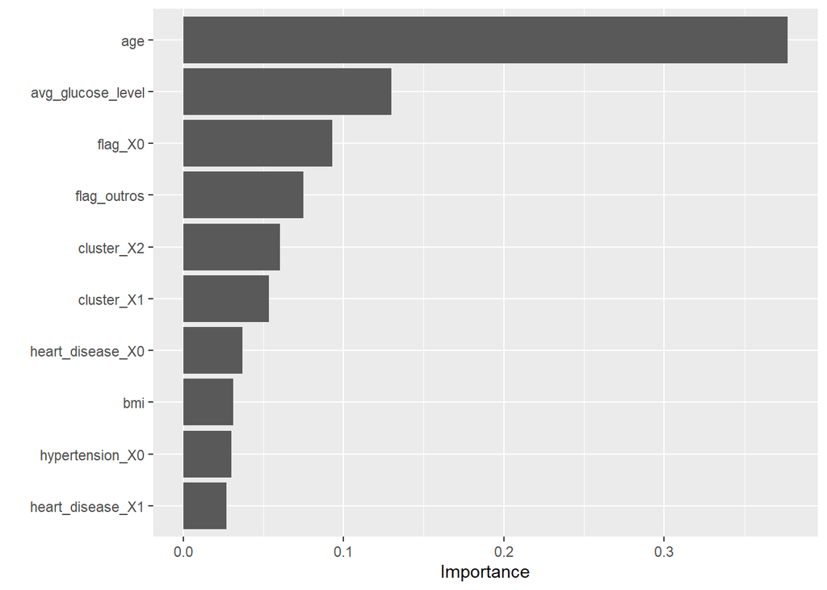

```r
# tempo #grid = 50, 161s

#faz o fit do modelo com o melhor conjunto de hiperparâmetros
boost_fit <- finalize_model(boost, parameters = best_xgb) %>%
  fit(stroke ~ ., treinamento_proc)

pred_xgbm <- predict(boost_fit, new_data = teste_proc, type = "prob")$.pred_1

desempenho <- desempenho %>%
                bind_rows(tibble(prob = pred_xgbm,
                                classes = ifelse(teste_proc$stroke == "1", "Yes", "No"),
                                metodo = "XGBM"))

# visualizando variáveis mais importantes
vip(boost_fit)
```

### Redes Neurais

Definição de estrutura e loading de pesos treinados

```r
#desempenho <- desempenho |> filter(metodo != "Neural Networks")

X_trn <- treinamento_proc %>% dplyr::select(-stroke) %>% as.matrix()
X_tst <- teste_proc %>% dplyr::select(-stroke) %>% as.matrix()

y_trn <- treinamento_proc$stroke %>% to_categorical()
y_tst <- teste_proc$stroke %>% to_categorical()

#net <- NULL
# Modelo Sequencial
net <- keras_model_sequential() %>%
  layer_dense(units = 512, activation = "relu", input_shape = ncol(X_trn)) %>%
  layer_dropout(rate = 0.4) %>%
  layer_dense(units = 256, activation = "relu") %>%
  layer_dropout(rate = 0.4) %>%
  layer_dense(units = 128, activation = "relu") %>%
  layer_dropout(rate = 0.3) %>%
  layer_dense(units = 64, activation = "relu") %>%
  layer_dropout(rate = 0.2) %>%
  layer_dense(units = 32, activation = "relu") %>%
  layer_dropout(rate = 0.2) %>%
  layer_dense(units = 16, activation = "relu") %>%
  layer_dropout(rate = 0.1) %>%
  layer_dense(units = 2, activation = "softmax")  # Camada de saída com ativação sigmoid


# definicao do estimador da rede neural
net %>%
  compile(loss = "categorical_crossentropy",
          optimizer = optimizer_rmsprop(),
          metrics = c("Recall")
          )

#accuracy Recall(sensibilidade) Precision

summary(net)
```

```
## Model: "sequential"
## ________________________________________________________________________________
##  Layer (type)                       Output Shape                    Param #
## ================================================================================
##  dense_6 (Dense)                    (None, 512)                     13824
##  dropout_5 (Dropout)                (None, 512)                     0
##  dense_5 (Dense)                    (None, 256)                     131328
##  dropout_4 (Dropout)                (None, 256)                     0
##  dense_4 (Dense)                    (None, 128)                     32896
##  dropout_3 (Dropout)                (None, 128)                     0
##  dense_3 (Dense)                    (None, 64)                      8256
##  dropout_2 (Dropout)                (None, 64)                      0
##  dense_2 (Dense)                    (None, 32)                      2080
##  dropout_1 (Dropout)                (None, 32)                      0
##  dense_1 (Dense)                    (None, 16)                      528
##  dropout (Dropout)                  (None, 16)                      0
##  dense (Dense)                      (None, 2)                       34
## ================================================================================
## Total params: 188946 (738.07 KB)
## Trainable params: 188946 (738.07 KB)
## Non-trainable params: 0 (0.00 Byte)
## ________________________________________________________________________________
```

Treina o modelo de redes neurais e salva

```r
tensorflow::set_random_seed(123)

# Definindo o callback de Early Stopping
callback <- callback_early_stopping(
  monitor = "val_loss",  # Métrica a ser monitorada
  patience = 50,          # Número de épocas para esperar após a parada de melhorias
  restore_best_weights = TRUE)  # Restaura os pesos do modelo para a melhor época


history <- net %>%
  fit(X_trn, y_trn, epochs = 10000,
      batch_size = 80, validation_split = 0.2, #DIVIDE O TOTAL DE DADOS EM 80 BLOCOS
      callbacks = list(callback)) #pega 20% pra validar enquanto roda

#plot(history)

# Salvando os pesos do modelo
save_model_weights_hdf5(net, "pesos_nn_1.h5")
```

carrega pesos salvos, prediz e carrega predição na base comparativa

```r
# Carregando os pesos salvos no modelo
net %>% load_model_weights_hdf5("pesos_nn_1.h5")

pred_nn <- predict(net, X_tst)[,2] #prob de apresentar o evento
```

```
## 32/32 - 0s - 121ms/epoch - 4ms/step
```

```r
desempenho <- desempenho %>%
                bind_rows(tibble(prob = pred_nn,
                                classes = ifelse(teste_proc$stroke == "1", "Yes", "No"),
                                metodo = "Neural Networks"))
```

### Modelo de redes neurais com 200 epocas (sem call back)

Treina o modelo de redes neurais e salva

```r
tensorflow::set_random_seed(42)

history <- net %>%
  fit(X_trn, y_trn, epochs = 200,
      batch_size = 80, validation_split = 0.2)

# Salvando os pesos do modelo
save_model_weights_hdf5(net, "pesos_nn_2.h5")
```

```r
# Carregando os pesos salvos no modelo
net %>% load_model_weights_hdf5("pesos_nn_2.h5")

pred_nn_2 <- predict(net, X_tst)[,2] #prob de apresentar o evento
```

```
## 32/32 - 0s - 84ms/epoch - 3ms/step
```

```r
desempenho <- desempenho %>%
                bind_rows(tibble(prob = pred_nn_2,
                                classes = ifelse(teste_proc$stroke == "1", "Yes", "No"),
                                metodo = "Neural Networks - sem callback"))
```

## Comparativo de todos os modelos

Como esperado redes neurais com callback teve melhor desempenho que sem callback

```r
desempenho %>%
  mutate(classes = factor(classes)) %>%
  group_by(metodo) %>%
  roc_auc(classes, prob, event_level = "second") %>%
  arrange(desc(.estimate))
```

```
## # A tibble: 8 × 4
##   metodo                         .metric .estimator .estimate
##   <chr>                          <chr>   <chr>          <dbl>
## 1 Elastic Net                    roc_auc binary         0.823
## 2 LM                             roc_auc binary         0.822
## 3 LASSO - interact               roc_auc binary         0.820
## 4 Neural Networks                roc_auc binary         0.818
## 5 XGBM                           roc_auc binary         0.803
## 6 Random Forest                  roc_auc binary         0.799
## 7 LM - interact                  roc_auc binary         0.782
## 8 Neural Networks - sem callback roc_auc binary         0.767
```

Curva AUC

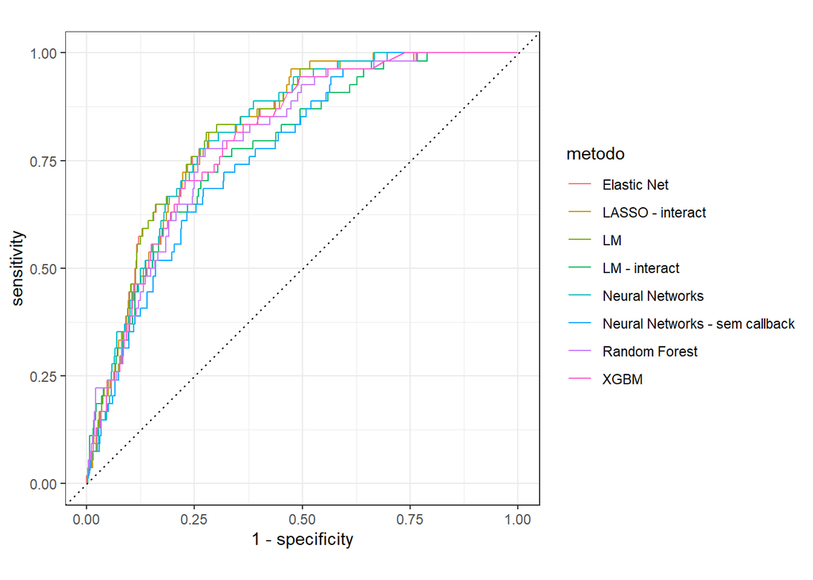

```r
desempenho %>%
  mutate(classes = factor(classes)) %>%
  group_by(metodo) %>%
  roc_curve(classes, prob, event_level = "second") %>%
  autoplot()
```

# Análise aprofundada dos modelos e pontos de corte

accuracy : acertos/casos totais

sensitivity/recall : acertos positivos/total de positivos

specificity : assertos negativos/total de negativos reais 1-specificity : erros negativos/total de negativos reais (% dos totais que não terão derrame que fizeram exame em vão)

ppv/precisão : assertos positivos/total de positivos previstos (% das pessoas chamadas que realmente terão derrame) npv : assertos negativos/total de negativos previstos (% das pessoas que não serão chamadas que realmente não terão derrame)

recall : assertos positivos/total de positivos reais

Crio função para calcular formula de campo para cada modelo para cada ponto de corte utilizando calculo que leve em consideração os pesos da sensibilidade e especificidade para o negócio em questão. Melhor modelo e melhor ponto de corte obtido:

```r
# Função para calcular o valor do campo
calc_campo <- function(pred, model_name) {
  coords(roc(teste_proc$stroke, pred), c(seq(.001,.5,.001)),
         ret = c("threshold","accuracy", "sensitivity", "specificity", "1-specificity", "ppv", "npv")) %>%
    mutate(campo = (sensitivity^3)*specificity, model = model_name)  %>%
    arrange(desc(campo))
}

# Lista de previsões
pred_list <- list(LASSO = pred_LASSO, lm = pred_lm, enet = pred_enet, rf = pred_rf, xgbm = pred_xgbm, nn = pred_nn,  nnscall = pred_nn_2)

# Aplica a função a cada conjunto de previsões
campo_values <- lapply(names(pred_list), function(x) calc_campo(pred_list[[x]], x))

# Combina os resultados em um data frame
campo_df <- do.call(rbind, campo_values)

# Retorna a linha com o maior valor do campo
campo_df[which.max(campo_df$campo), ]
```

```
##   threshold accuracy sensitivity specificity 1-specificity     ppv   npv  campo
## 1     0.021   0.5372       0.963      0.5134        0.4866 0.09943 0.996 0.4585
##   model
## 1 LASSO
```

Matriz de confusão do melhor modelo e ponto de corte

```r
corte <- 0.021

previsoes_1_1 <- ifelse(pred_LASSO >= corte, 1, 0) %>% as.tibble

previsoes_1_1 <- previsoes_1_1 %>% bind_cols(tibble(obs = teste_proc$stroke))

table(previsoes_1_1) |> `dimnames<-`(list(previsto = c("0", "1"), real = c("0", "1")))
```

```
##         real
## previsto   0   1
##        0 497   2
##        1 471  52
```

De que forma podemos obter ganhos diretos para os pacientes? E se quisermos dar prioridade para casos com probabilidade de derrame mais elevada?

pro ponto de corte de 20% qual modelo possui melhor valor de “campo” ?

**xgbm é o melhor modelo para um ponto de corte de 20% de probabilidade de derrame**

```r
#escolhe a resposta com maior campo. desta vez sensibilidade (quem é deixado de fora) tem peso normal pois step anterior já leva ela em consideração

# Função para calcular o valor do campo
calc_campo <- function(pred) {
  coords(roc(teste_proc$stroke, pred), .2,
         ret = c("threshold","accuracy", "sensitivity", "specificity", "1-specificity", "ppv", "npv")) %>%
    mutate(campo = (sensitivity^1)*specificity*10) %>%
    pull(campo)
}

# Lista de previsões
pred_list <- list(LASSO = pred_LASSO, lm = pred_lm, enet = pred_enet, rf = pred_rf, xgbm = pred_xgbm, nn = pred_nn,  nnscall = pred_nn_2)

# Aplica a função a cada conjunto de previsões
(campo_values <- lapply(pred_list, calc_campo))
```

```
## $LASSO
## [1] 1.081
##
## $lm
## [1] 1.61
##
## $enet
## [1] 1.61
##
## $rf
## [1] 2.169
##
## $xgbm
## [1] 4.637
##
## $nn
## [1] 1.422
##
## $nnscall
## [1] 2.228
```

Lista de prioridade de exames obtida após executar os modelos:

```r
corte <- 0.2 #20%

previsoes_2 <- ifelse(pred_xgbm >= corte, 1, 0) %>% as.tibble %>% setNames("valor2")

lista_prioritaria <- teste_proc %>%
                bind_cols(previsoes_1_1) %>% bind_cols(previsoes_2)

lista_prioritaria  <- lista_prioritaria %>% mutate(resultado=ifelse(value == 1, "em risco", "sem risco"),
                                                   resultado = ifelse(valor2 == 1, "urgente", resultado)) %>% dplyr::select(-value, -valor2)

lista_prioritaria$resultado %>% table()
```

```
## .
##  em risco sem risco   urgente
##       333       499       190
```

Percentual de pacientes que teriam derrame e ficariam de fora (falsos negativos):

```r
(lista_prioritaria %>% filter(resultado == 'sem risco' & stroke == 1) %>% nrow()/lista_prioritaria %>% dplyr::filter(stroke == 1) %>% nrow())*100
```

```
## [1] 3.704
```

Percentual de exames diminuidos:

```r
#Percentual de exames diminuidos
(1-(lista_prioritaria %>% filter(resultado != 'sem risco') %>% nrow()/nrow(previsoes_1_1)))*100
```

```
## [1] 48.83
```

Geramos uma lista indicando se o paciente precisará ou não realizar um exame e, caso necessário, classificamos como “urgente” aqueles com probabilidade igual ou superior a 20% de apresentar um derrame.

Curiosamente, um dos modelos com AUC mais baixa em comparação com os outros (XGBM) foi o mais eficaz na previsão de casos críticos (probabilidade de AVC acima de 20%). Isso demonstra que, para modelos de classificação, é mais importante ter um modelo específico para o problema em questão do que um modelo com maior AUC para todos os pontos de corte.